# Predicting the Demand for Rented Bikes in Seoul Considering Time and Weather Variables

by GitChuds: Ethan, Miles, Freddie, Daniel & Zack

2026-11-27

```r
# load data
seoul_bikes_raw <- read_csv("data/SeoulBikeData.csv", locale=locale(encoding="latin1"))
#extracting raw data, locale needed to be specified as error otherwise.

#clean data
seoul_bikes <- seoul_bikes_raw |>
  clean_names() |> #cleaning names to snake_case, as column headings' words initially separated with space
  select(-functioning_day)
```

## Introduction

In this project, we will be analysing the demand for rented bikes in Seoul, with the aims of **predicting the demand for rented bikes in Seoul considering time and weather variables.** This predictive model will be useful for helping to maintain a stable supply for bike renters, as well as help rented bike companies to project revenues in the future.

## Data

### Raw Dataset

The Seoul rented bikes data set has 8760 observations across 14 features. Each observation records details of the date, hourly bike demand, hour of day, temperature, rainfall, snowfall and other time and weather related-variables.

### Cleaning

In the raw data set, a variable called functioning_day was used to signify if the bike-renting system was operational or not. We realised that when functioning_day == “no,” all instances of rented_bike_count had a value of 0. As we are interested in the number of rented bikes, this would not be relevant for our goal.

We also used clean_names() to ensure that all variables have in snake_case for simplicity when writing code.

### Feature Engineering

We ultimately engineered three variables, but one of which will not be used in our linear model, which will be explained in later sections of this report.

precipitation — has values 1 or 0, used to indicate if there was any forms of rainfall or snowfall.

is_weekend — determines if the day is a weekday or during the weekend.

For our model the following variables are what we will consider: rented_bike_count, hour, holiday, is_weekend, temperature_c, humidity_percent, seasons and precipitation.

Below is a variable table of the clean data:

| Variable Name | Type | Description |
| --- | --- | --- |
| rented_bike_count | numerical | number of bikes rented per hour |
| hour | categorical | describes the hour of day, categorical data as it will be used as a factor |
| holiday | categorical | determines if the day is a holiday or not |
| is_weekend | categorical | determines if it is a day in the week or in the weekend |
| temperature_c | numerical | temperature of Seoul in degrees Celsius |
| humidity_percent | numerical | humidity of Seoul in percent |
| seasons | categorical | determines if the day is in winter, spring, summer or autumn |
| precipitation | numerical | has values 1 or 0 used to determine if there was any precipitation during the hour of day |

## Initial Findings

### Temperature vs. Number of Rented Bikes in Specific Time Windows

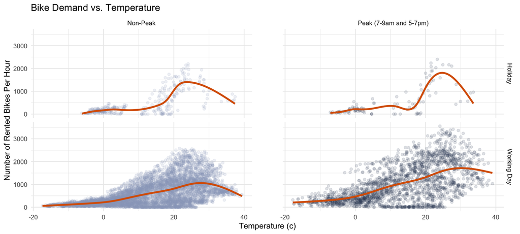

In the graph above, we first see that no matter the time period or day (i.e holiday vs. non-holiday), that the demanded for rented bikes increases as temperatures increases, with its optimal range at approximately 25-28°C.

After that range, demand begins to drop off.

Additionally, demand is substantially higher during peak hours on working days, vs. non-peak hours on working days, as they have maximum values of approximately 3600 versus 2600 rented bikes at their peaks.

However, this gap disappears on holidays, where the maximum values for rented bike demand during peak and non-peak hours are within the range of 2200-2400 rented bikes.

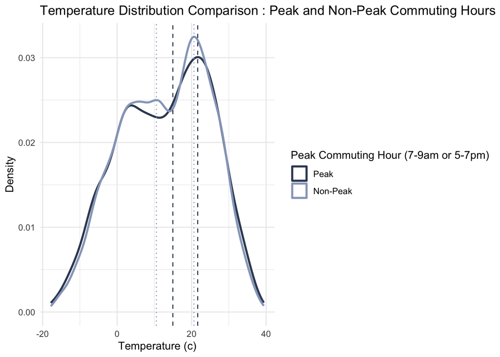

The both graphs are almost overlapping. This means that peak and non-peak commuting hours overlap almost completely across the entire temperature range (-20-40°C).

This means that higher bike demand seen during working-day peak hours are actually driven by commuting behaviour, rather than due to peak hours occuring during warmer weather. In other words, temperature is not a confounding factor.

Both groups also have the same bimodal, with peaks between approximately 4-11°C and 21-22°C, and a small dip in between. This reflects Seoul’s climate of long, hot summers and long, cold winters, where the autumn and spring seasons are shorter.

This also shows how Seoul’s seasonal temperature cycles affect peak and non-peak hours relatively equally.

### Seasons vs. Rented Bike Count considering Holidays

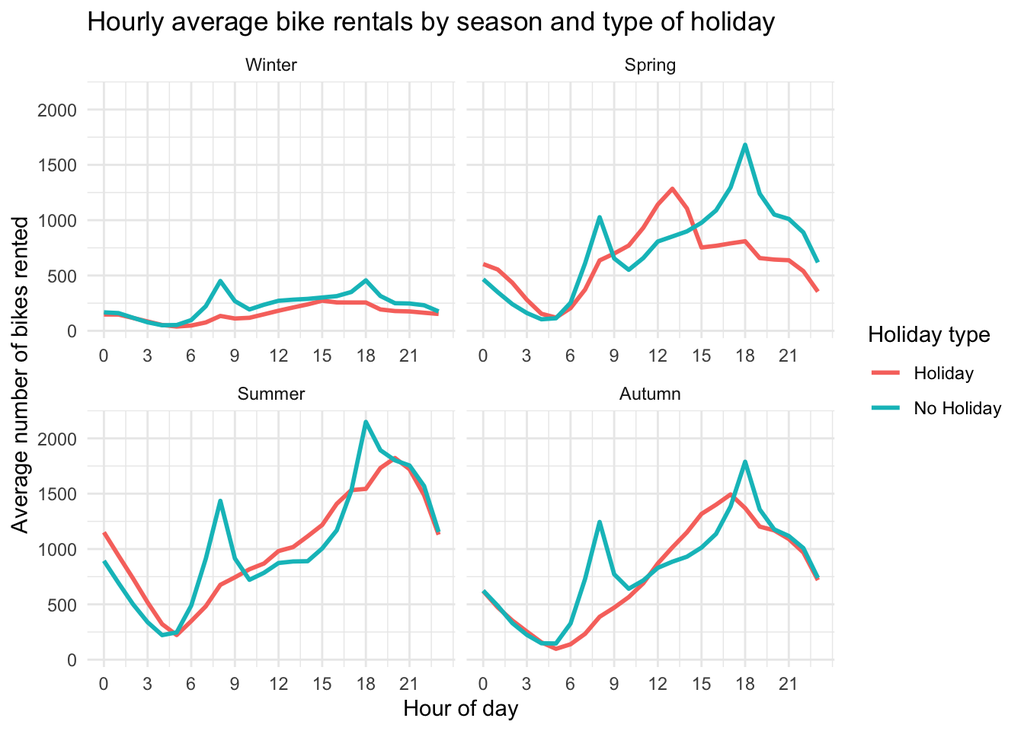

I learned that the temperature and season variables play an important role in predicting bike rental demand in Seoul. Demand is highest during summer and lowest during winter, suggesting that temperature affects people’s willingness to cycle. In addition, on non-holidays, demand consistently peaks around 8 am and 6 pm, reflecting typical commuting hours, while on holidays demand tends to increase more gradually throughout the day. These patterns indicate that the relationship between time of day and bike rental demand varies depending on the season and whether it is a holiday.

Therefore, incorporating both these variables into our predictive model could improve its accuracy, and through further modeling we could determine the individual impact of specific weather factors such as temperature, rainfall, and humidity.

### Precipitation vs. Rented Bike Count

#### Rainfall vs. Rented Bike Count

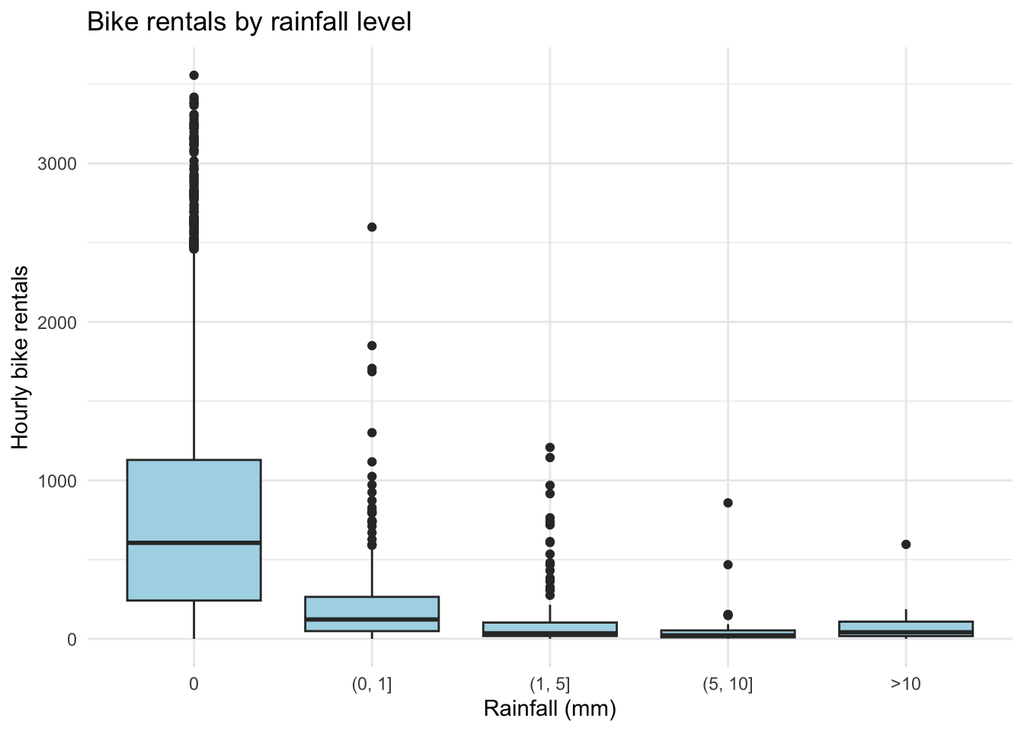

#### Snowfall vs. Rented Bike Count

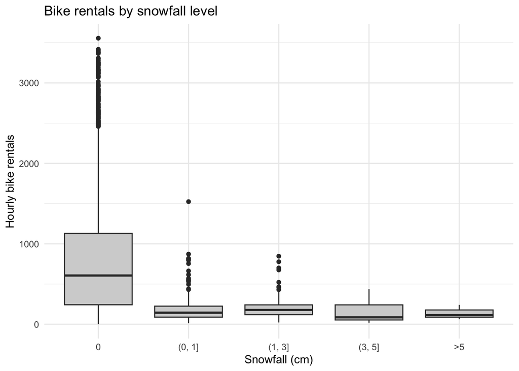

### Behaviour of Rented Bike Count on Weekdays Compared to Weekends & Holidays

```r
seoul_bikes <- seoul_bikes %>%
  mutate(
    day_type = if_else(
      lubridate::wday(as.Date(date, format = "%d/%m/%Y"),
                      week_start = 1) >= 6 | holiday == "Holiday",
      "Weekend/Holiday",
      "Weekday"
    )
  )
```

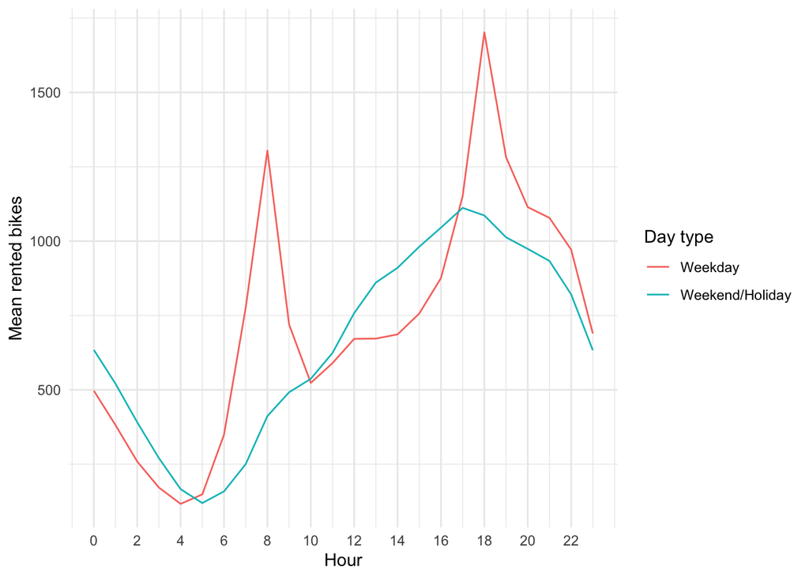

```r
hour_profile <- seoul_bikes |>
group_by(day_type, hour) |>
summarise(
mean_rented_bikes = mean(`rented_bike_count`,na.rm = TRUE),
.groups = "drop"
)

ggplot(hour_profile, aes(x = hour, y = mean_rented_bikes, colour = day_type)) +
geom_line() +
labs(x = "Hour", y = "Mean rented bikes", colour = "Day type"
) +
  scale_x_continuous(breaks = seq(0, 23, by = 2)) +
theme_minimal()
```

```r
hour_profile |>
group_by(day_type) |>
slice_max(mean_rented_bikes, n = 1)
```

```
## # A tibble: 2 × 3
## # Groups:   day_type [2]
##   day_type         hour mean_rented_bikes
##   <chr>           <dbl>             <dbl>
## 1 Weekday            18             1702.
## 2 Weekend/Holiday    17             1112.
```

## Modelling

### Simplified Dataset

Below is the first 10 rows of the clean data set we will be using for modelling:

```
## # A tibble: 10 × 10
##    rented_bike_count hour  holiday    is_weekend temperature_c humidity_percent
##                <dbl> <fct> <chr>      <lgl>              <dbl>            <dbl>
##  1               254 0     No Holiday FALSE               -5.2               37
##  2               204 1     No Holiday FALSE               -5.5               38
##  3               173 2     No Holiday FALSE               -6                 39
##  4               107 3     No Holiday FALSE               -6.2               40
##  5                78 4     No Holiday FALSE               -6                 36
##  6               100 5     No Holiday FALSE               -6.4               37
##  7               181 6     No Holiday FALSE               -6.6               35
##  8               460 7     No Holiday FALSE               -7.4               38
##  9               930 8     No Holiday FALSE               -7.6               37
## 10               490 9     No Holiday FALSE               -6.5               27
## # ℹ 4 more variables: seasons <chr>, precipitation <dbl>,
## #   solar_radiation_mj_m2 <dbl>, wind_speed_m_s <dbl>
```

### Linear Models

We will be considering two models, one where we interact hour and holiday together, and one where hour and holiday are separately considered in the model.

The reason we are considering the interaction between hour and holiday for a model is because from our EDA we determined that the number of rented bikes given a specific hour behaves very differently when it is a holiday and when it is not.

Considering their interaction may provide us with more accuracy in terms of predictions.

Model 1: Linear Regression with Hour-Holiday Interaction (55 Terms)

| term | estimate | std.error | statistic | p.value |
| --- | --- | --- | --- | --- |
| (Intercept) | 903.26 | 115.79 | 7.80 | 0.00 |
| is_weekendTRUE | -68.74 | 10.79 | -6.37 | 0.00 |
| temperature_c | 20.38 | 0.92 | 22.24 | 0.00 |
| humidity_percent | -6.70 | 0.31 | -21.47 | 0.00 |
| precipitation | -247.01 | 17.81 | -13.87 | 0.00 |
| hour_X1 | -80.61 | 150.24 | -0.54 | 0.59 |
| hour_X2 | -99.72 | 159.95 | -0.62 | 0.53 |
| hour_X3 | -260.38 | 154.53 | -1.69 | 0.09 |
| hour_X4 | -425.06 | 171.61 | -2.48 | 0.01 |
| hour_X5 | -409.91 | 154.52 | -2.65 | 0.01 |
| hour_X6 | -248.75 | 152.27 | -1.63 | 0.10 |
| hour_X7 | -225.86 | 159.98 | -1.41 | 0.16 |
| hour_X8 | -99.96 | 152.26 | -0.66 | 0.51 |
| hour_X9 | -133.22 | 157.08 | -0.85 | 0.40 |
| hour_X10 | -155.45 | 157.14 | -0.99 | 0.32 |
| hour_X11 | -187.78 | 171.59 | -1.09 | 0.27 |
| hour_X12 | -109.49 | 160.12 | -0.68 | 0.49 |
| hour_X13 | -56.71 | 152.47 | -0.37 | 0.71 |
| hour_X14 | -65.70 | 152.48 | -0.43 | 0.67 |
| hour_X15 | 74.61 | 163.49 | 0.46 | 0.65 |
| hour_X16 | 6.42 | 154.81 | 0.04 | 0.97 |
| hour_X17 | 94.46 | 154.64 | 0.61 | 0.54 |
| hour_X18 | 230.52 | 160.02 | 1.44 | 0.15 |
| hour_X19 | -17.53 | 159.97 | -0.11 | 0.91 |
| hour_X20 | 138.98 | 154.54 | 0.90 | 0.37 |
| hour_X21 | 77.43 | 154.52 | 0.50 | 0.62 |
| hour_X22 | -24.05 | 154.52 | -0.16 | 0.88 |
| hour_X23 | -28.87 | 163.26 | -0.18 | 0.86 |
| holiday_No.Holiday | -29.98 | 115.86 | -0.26 | 0.80 |
| seasons_Spring | -66.15 | 13.85 | -4.78 | 0.00 |
| seasons_Summer | 11.12 | 17.91 | 0.62 | 0.53 |
| seasons_Winter | -283.33 | 20.59 | -13.76 | 0.00 |
| hour_X1_x_holiday_No.Holiday | -22.30 | 154.24 | -0.14 | 0.89 |
| hour_X2_x_holiday_No.Holiday | -102.53 | 163.69 | -0.63 | 0.53 |
| hour_X3_x_holiday_No.Holiday | -31.21 | 158.47 | -0.20 | 0.84 |
| hour_X4_x_holiday_No.Holiday | 64.13 | 175.07 | 0.37 | 0.71 |
| hour_X5_x_holiday_No.Holiday | 74.72 | 158.33 | 0.47 | 0.64 |
| hour_X6_x_holiday_No.Holiday | 84.53 | 156.19 | 0.54 | 0.59 |
| hour_X7_x_holiday_No.Holiday | 373.82 | 163.68 | 2.28 | 0.02 |
| hour_X8_x_holiday_No.Holiday | 626.09 | 156.29 | 4.01 | 0.00 |
| hour_X9_x_holiday_No.Holiday | 236.47 | 160.88 | 1.47 | 0.14 |
| hour_X10_x_holiday_No.Holiday | 55.58 | 160.93 | 0.35 | 0.73 |
| hour_X11_x_holiday_No.Holiday | 104.57 | 175.08 | 0.60 | 0.55 |
| hour_X12_x_holiday_No.Holiday | 63.99 | 163.72 | 0.39 | 0.70 |
| hour_X13_x_holiday_No.Holiday | 13.81 | 156.21 | 0.09 | 0.93 |
| hour_X14_x_holiday_No.Holiday | 35.99 | 156.28 | 0.23 | 0.82 |
| hour_X15_x_holiday_No.Holiday | -36.75 | 166.93 | -0.22 | 0.83 |
| hour_X16_x_holiday_No.Holiday | 132.24 | 158.36 | 0.84 | 0.40 |
| hour_X17_x_holiday_No.Holiday | 311.73 | 158.40 | 1.97 | 0.05 |
| hour_X18_x_holiday_No.Holiday | 591.77 | 163.71 | 3.61 | 0.00 |
| hour_X19_x_holiday_No.Holiday | 557.67 | 163.70 | 3.41 | 0.00 |
| hour_X20_x_holiday_No.Holiday | 313.85 | 158.33 | 1.98 | 0.05 |
| hour_X21_x_holiday_No.Holiday | 384.16 | 158.43 | 2.42 | 0.02 |
| hour_X22_x_holiday_No.Holiday | 369.68 | 158.39 | 2.33 | 0.02 |
| hour_X23_x_holiday_No.Holiday | 153.23 | 167.02 | 0.92 | 0.36 |

Model 2: Linear Regression without Interaction (32 Terms)

| term | estimate | std.error | statistic | p.value |
| --- | --- | --- | --- | --- |
| (Intercept) | 728.63 | 40.71 | 17.90 | 0.00 |
| is_weekendTRUE | -68.84 | 10.83 | -6.36 | 0.00 |
| temperature_c | 20.48 | 0.92 | 22.26 | 0.00 |
| humidity_percent | -6.73 | 0.31 | -21.47 | 0.00 |
| precipitation | -245.86 | 17.87 | -13.76 | 0.00 |
| hour_X1 | -99.47 | 34.15 | -2.91 | 0.00 |
| hour_X2 | -197.92 | 34.19 | -5.79 | 0.00 |
| hour_X3 | -288.69 | 34.43 | -8.38 | 0.00 |
| hour_X4 | -365.06 | 34.37 | -10.62 | 0.00 |
| hour_X5 | -338.09 | 33.89 | -9.98 | 0.00 |
| hour_X6 | -167.16 | 34.11 | -4.90 | 0.00 |
| hour_X7 | 131.39 | 34.20 | 3.84 | 0.00 |
| hour_X8 | 492.68 | 34.54 | 14.26 | 0.00 |
| hour_X9 | 92.12 | 34.15 | 2.70 | 0.01 |
| hour_X10 | -102.54 | 34.49 | -2.97 | 0.00 |
| hour_X11 | -89.49 | 34.85 | -2.57 | 0.01 |
| hour_X12 | -49.38 | 34.95 | -1.41 | 0.16 |
| hour_X13 | -43.07 | 35.07 | -1.23 | 0.22 |
| hour_X14 | -30.93 | 35.42 | -0.87 | 0.38 |
| hour_X15 | 37.49 | 35.43 | 1.06 | 0.29 |
| hour_X16 | 131.75 | 34.99 | 3.77 | 0.00 |
| hour_X17 | 390.33 | 34.89 | 11.19 | 0.00 |
| hour_X18 | 794.81 | 34.78 | 22.85 | 0.00 |
| hour_X19 | 514.48 | 34.49 | 14.92 | 0.00 |
| hour_X20 | 437.60 | 33.97 | 12.88 | 0.00 |
| hour_X21 | 442.56 | 34.28 | 12.91 | 0.00 |
| hour_X22 | 327.63 | 34.10 | 9.61 | 0.00 |
| hour_X23 | 117.14 | 34.59 | 3.39 | 0.00 |
| holiday_No.Holiday | 153.47 | 23.17 | 6.62 | 0.00 |
| seasons_Spring | -66.23 | 13.91 | -4.76 | 0.00 |
| seasons_Summer | 10.31 | 17.98 | 0.57 | 0.57 |
| seasons_Winter | -282.22 | 20.67 | -13.65 | 0.00 |

Model 3: Splines

| term | estimate | std.error | statistic | p.value |
| --- | --- | --- | --- | --- |
| (Intercept) | 535.27 | 38.99 | 13.73 | 0.00 |
| is_weekendTRUE | 79.27 | 39.81 | 1.99 | 0.05 |
| temperature_c | 16.12 | 1.77 | 9.13 | 0.00 |
| precipitation | -209.58 | 17.18 | -12.20 | 0.00 |
| wind_speed_m_s | -21.09 | 5.10 | -4.14 | 0.00 |
| hour_ns_1 | 684.94 | 40.25 | 17.02 | 0.00 |
| hour_ns_2 | -619.06 | 62.62 | -9.89 | 0.00 |
| hour_ns_3 | 151.56 | 52.23 | 2.90 | 0.00 |
| hour_ns_4 | 463.76 | 43.63 | 10.63 | 0.00 |
| hour_ns_5 | -424.18 | 70.40 | -6.03 | 0.00 |
| hour_ns_6 | 308.62 | 34.69 | 8.90 | 0.00 |
| humidity_percent_poly_1 | -7600.30 | 550.18 | -13.81 | 0.00 |
| humidity_percent_poly_2 | -4711.92 | 423.78 | -11.12 | 0.00 |
| solar_radiation_mj_m2_poly_1 | 11411.52 | 968.98 | 11.78 | 0.00 |
| solar_radiation_mj_m2_poly_2 | -2642.88 | 518.41 | -5.10 | 0.00 |
| holiday_No.Holiday | 130.26 | 21.11 | 6.17 | 0.00 |
| seasons_Spring | -61.94 | 13.05 | -4.75 | 0.00 |
| seasons_Summer | 16.57 | 16.46 | 1.01 | 0.31 |
| seasons_Winter | -280.32 | 18.87 | -14.85 | 0.00 |
| hour_ns_1_x_temperature_c | -0.36 | 2.41 | -0.15 | 0.88 |
| hour_ns_2_x_temperature_c | -16.75 | 3.00 | -5.58 | 0.00 |
| hour_ns_3_x_temperature_c | -4.48 | 2.57 | -1.75 | 0.08 |
| hour_ns_4_x_temperature_c | 46.34 | 2.25 | 20.64 | 0.00 |
| hour_ns_5_x_temperature_c | 0.78 | 4.06 | 0.19 | 0.85 |
| hour_ns_6_x_temperature_c | 22.14 | 1.94 | 11.41 | 0.00 |
| hour_ns_1_x_is_weekendTRUE | -1022.70 | 58.55 | -17.47 | 0.00 |
| hour_ns_2_x_is_weekendTRUE | 430.74 | 72.71 | 5.92 | 0.00 |
| hour_ns_3_x_is_weekendTRUE | -30.65 | 64.92 | -0.47 | 0.64 |
| hour_ns_4_x_is_weekendTRUE | -549.29 | 57.98 | -9.47 | 0.00 |
| hour_ns_5_x_is_weekendTRUE | -2.52 | 101.98 | -0.02 | 0.98 |
| hour_ns_6_x_is_weekendTRUE | -225.54 | 49.15 | -4.59 | 0.00 |

Below is the expression of the first model (with each of the slopes rounded to 2 decimal places):

$$\begin{aligned}
\widehat{\text{rented_bike_count}} &= 903.26 - 68.74 \times
\text{is_weekend} + 20.38 \times \text{temperature_c} - 6.70 \times
\text{humidity_percent} \\
&\quad - 247.01 \times \text{precipitation} - 80.61 \times
\text{hour_holiday_X1_Holiday} - 99.72 \times
\text{hour_holiday_X2_Holiday} + \dots \\
&\quad - 29.98 \times \text{hour holiday X0 No.Holiday} - 132.89
\times \text{hour holiday X1 No.Holiday} + \dots \\
&\quad - 66.15 \times \text{seasons_Spring} + 11.12 \times
\text{seasons_Summer} - 283.33 \times \text{seasons_Winter}
\end{aligned}$$

Below is the expression of the second model (with each of the slopes rounded to 2 decimal places):

$$\begin{aligned}
\widehat{\text{rented_bike_count}} &= 728.63 -68.83 \times
\text{is_weekend} + 20.48 \times \text{temperature_c} - 6.73 \times
\text{humidity_percent} \\
&\quad - 245.86 \times \text{precipitation} - 99.47 \times
\text{hour_X1} - 197.92 \times \text{hour_X2} + \dots \\
&\quad + 153.47 \times \text{holiday_No.Holiday} - 66.23 \times
\text{seasons_Spring} + 10.31 \times \text{seasons_Summer} \\
&\quad - 282.22 \times \text{seasons_Winter}
\end{aligned}$$

### Results and Residual Graphs of Predictions

Below are some summary statistics that compare the predicted values of models 1, 2 and the real rented_bike_counts.

```
## # A tibble: 4 × 13
##   column             n  mean    sd median trimmed   mad   min   max range   skew
##   <chr>          <dbl> <dbl> <dbl>  <dbl>   <dbl> <dbl> <dbl> <dbl> <dbl>  <dbl>
## 1 Model 1 Pred    1752  707.  497.   727.    715.  349. -708. 2053. 2761. -0.117
## 2 Model 2 Pred    1752  707.  496.   732.    716.  348. -823. 2035. 2858. -0.142
## 3 Model 3 Pred    1752  690.  503.   665.    665.  355. -529. 2192. 2721.  0.402
## 4 Real Bike Cou…  1752  700.  631.   522.    609.  372.    0  3404  3404   1.21
## # ℹ 2 more variables: kurtosis <dbl>, se <dbl>
```

#### Evaluation Metrics

Model Evaluation Metrics (Testing Data)

| model | num_terms | rmse | min | max | rsq | adj_rsq |
| --- | --- | --- | --- | --- | --- | --- |
| Model 1 | 55 | 410.1877 | 0 | 3404 | 0.5780 | 0.5646 |
| Model 2 | 32 | 411.6669 | 0 | 3404 | 0.5750 | 0.5673 |
| Model 3 | 31 | 376.6160 | 0 | 3404 | 0.6438 | 0.6375 |

RMSE: 411.6669 - across test-set observations between 0 and 3404 bikes per hour, this value corresponds to roughly 12.1% of the total demand range.

R-Squared: 0.575 - 57.5% of variance in the hourly rented bike counts is explained by model 2 on our testing dataset.

#### Residual Graphs

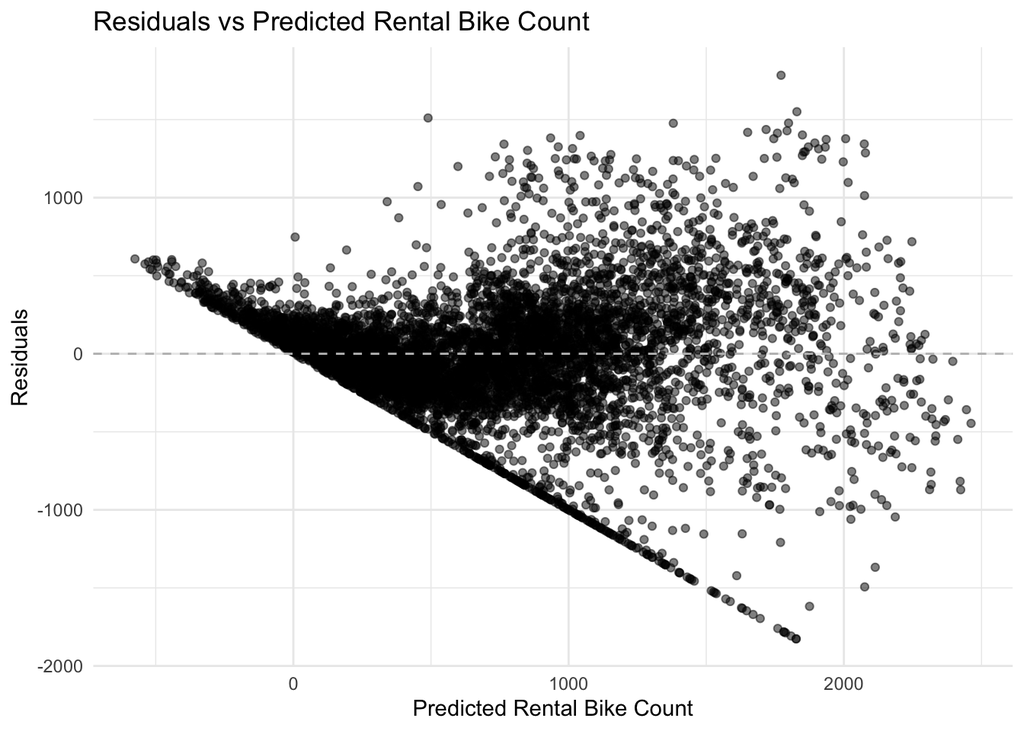

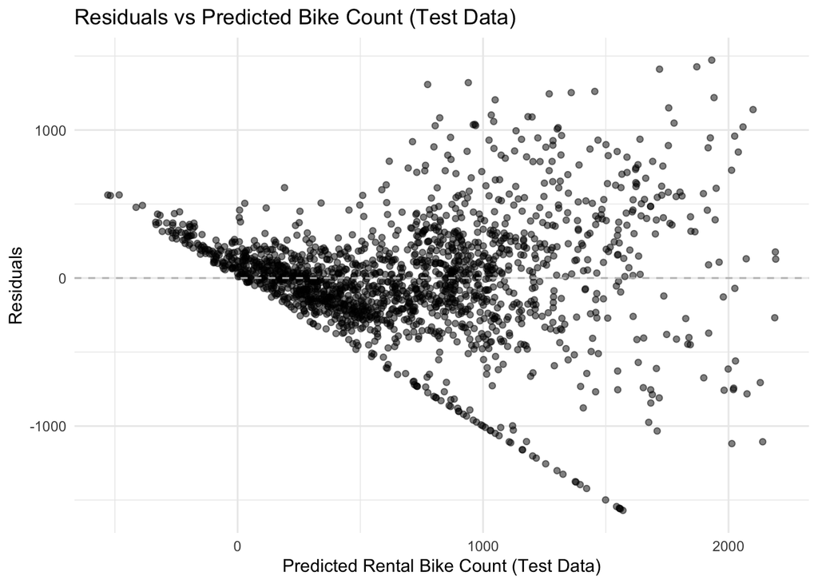

## Limitations

1. **Bike-demand is non-linear** when considered with multiple variables within the dataset, e.g. temperature, hour of day, precipitation etc. This is also proven by the residual graphs.
2. Combining variables for simplicity into a binary variable of the model, namely the use of precipitation **decreases the accuracy** of our model.
3. **Model can predict negative bike counts**, which are impossible, considering real values are above 0
4. **Omitted contextual variables**, e.g. public transport disruptions, major local events etc. leaves approximately 42.5% of variance unexplained.

## Conclusion

Overall, our investigation demonstrated that both time and weather variables are useful in predicting bike rental demand in Seoul. Demand is generally higher during warmer weather, summer months and peak commuting hours, while rainfall, snowfall and colder temperatures are associated with lower demand. Our linear regression model achieved a testing R-squared value of 0.575, indicating moderate predictive performance. Hypothesis testing also showed that 26 out of 31 slope coefficients were statistically significant at the 5% significance level before adjusting for multiple testing. However, the model has several limitations, including non-linear relationships, loss of information regarding precipitation severity and negative predictions. Despite these limitations, our model provides a useful starting point for predicting bike rental demand, which could help bike rental companies manage their bike supply and estimate future revenues. Further improvements could be made by incorporating additional variables and exploring more flexible modelling techniques.

## Generative AI Disclosure

Google Gemini was used during EDA, in particular when writing a reusable helper function for the density plots of temperature vs. density at peak and non-peak commuting hours.The specific line is shown below:

```r
determine_density_maxes <- function(df, max_var, max_var_condition, density_var){ #parameters to keep generality of function
  density_df <- df |>
  filter({{ max_var }} == max_var_condition)
  ##...
}
```

Additionally, it was also used for the bike demand vs. temperature graph for simplifying an if-statement. The specific line is shown below:

```r
seoul_bikes <- seoul_bikes |>
  mutate(
    peak = ifelse(hour %in% c(7:9, 17:19), TRUE, FALSE)
    #used Gemini to help with shortening the conditional statement, as initially was hour == 7 | hour == 8 | ...
  )
```

When evaluating performance of the models, Google Gemini was used to aid the computation of adjusted r-squared and the formatting of the output of the metrics, for the tested data. The specific chunk is shown below:

```r
eval_model <- function(pred_df, wflow, model){
  std_metrics <- pred_df |>
    bikes_metrics(truth = rented_bike_count, estimate = .pred) |>
    select(.metric, .estimate) |>
    pivot_wider(names_from = .metric, values_from = .estimate)

  n <- nrow(pred_df)
  p <- nrow(tidy(wflow)) - 1 #-1 because of the baseline
  min <- min(pred_df$rented_bike_count)
  max <- max(pred_df$rented_bike_count)

  std_metrics |>
    mutate(
      model = model,
      num_terms = p+1, #+1 here as the total number of terms includes the baseline
      adj_rsq = 1 - ((1 - rsq) * (n-1)) / (n - p - 1),
      min = min,
      max = max
    ) |>
    select(model, num_terms, rmse, min, max, rsq, adj_rsq)
}
```

## References

Easwaramoorthy, Sathishkumar Veerappampalayam . 2020. Seoul Bike Sharing Demand. UCI Machine Learning Repository. https://doi.org/10.24432/C5F62R.